# SDS M1 Group Assignment

Andreas Jørgensen, Cathrine Olsen, Louise Christoffersen & Mette Møller

1-10-2020

```r
library(readr)
library(tidyverse)
library(magrittr)
library(FactoMineR)
library(factoextra)
library(uwot)
library(GGally)
library(tidymodels)
library(mlbench)
library(glmnet)
library(xgboost)
library(vip)
library(ranger)
library(ggpubr) #package that helps mixing multiple plots on the same page
```

```r
student_raw <- read_csv("student-por.csv")
```

# Introduction

For this assignment a data set about Portuguese students has been chosen. The data set contains different information about the students regarding their life and activities in and out of school. The data is a combination of survey data about the students out of school life and data registered by the schools about the students performance. The survey was constructed as closed questions (i.e. the questions had options as answers). An explanation of all the variables can be found at [Kaggle](https://www.kaggle.com/uciml/student-alcohol-consumption?fbclid=IwAR2kTbpQrPvPI75kciD2x8p0Mrov139AhA-RKijUgf70i3BiW63P4Ga5A4g).

The purpose of this assignment is to investigate if there are any notable connections between students demographic, social life, school performance and the final grade (G3) they are given. This will be done by first doing a short exploration of the data set followed by a dimensionality reduction through PCA and clustering analysis with k-means using unsupervised machine learning. Finally supervised machine learning techniques are applied to a classification problem in order to train and select the best model to predict the final grades of students.

```r
student_raw %>%
  glimpse()
```

```
Rows: 649
Columns: 33
$ school     <chr> "GP", "GP", "GP", "GP", "GP", "GP", "GP", "GP", "GP", "GP", "GP", "GP", "GP", "GP", "GP", "GP", "GP", "GP", "GP", "GP", "GP", "GP", "G...
$ sex        <chr> "F", "F", "F", "F", "F", "M", "M", "F", "M", "M", "F", "F", "M", "M", "M", "F", "F", "F", "M", "M", "M", "M", "M", "M", "F", "F", "M",...
$ age        <dbl> 18, 17, 15, 15, 16, 16, 16, 17, 15, 15, 15, 15, 15, 15, 15, 16, 16, 16, 17, 16, 15, 15, 16, 16, 15, 16, 15, 15, 16, 16, 15, 15, 15, 15...
$ address    <chr> "U", "U", "U", "U", "U", "U", "U", "U", "U", "U", "U", "U", "U", "U", "U", "U", "U", "U", "U", "U", "U", "U", "U", "U", "R", "U", "U",...
$ famsize    <chr> "GT3", "GT3", "LE3", "GT3", "GT3", "LE3", "LE3", "GT3", "LE3", "GT3", "GT3", "GT3", "LE3", "GT3", "GT3", "GT3", "GT3", "GT3", "GT3", "...
$ Pstatus    <chr> "A", "T", "T", "T", "T", "T", "T", "A", "A", "T", "T", "T", "T", "T", "A", "T", "T", "T", "T", "T", "T", "T", "T", "T", "T", "T", "T",...
$ Medu       <dbl> 4, 1, 1, 4, 3, 4, 2, 4, 3, 3, 4, 2, 4, 4, 2, 4, 4, 3, 3, 4, 4, 4, 4, 2, 2, 2, 2, 4, 3, 4, 4, 4, 4, 3, 3, 2, 4, 4, 3, 2, 2, 4, 4, 2, 2,...
$ Fedu       <dbl> 4, 1, 1, 2, 3, 3, 2, 4, 2, 4, 4, 1, 4, 3, 2, 4, 4, 3, 2, 3, 3, 4, 2, 2, 4, 2, 2, 2, 4, 4, 4, 4, 3, 3, 2, 3, 3, 4, 4, 2, 2, 4, 4, 2, 2,...
$ Mjob       <chr> "at_home", "at_home", "at_home", "health", "other", "services", "other", "other", "services", "other", "teacher", "services", "health"...
$ Fjob       <chr> "teacher", "other", "other", "services", "other", "other", "other", "teacher", "other", "other", "health", "other", "services", "other...
$ reason     <chr> "course", "course", "other", "home", "home", "reputation", "home", "home", "home", "home", "reputation", "reputation", "course", "cour...
$ guardian   <chr> "mother", "father", "mother", "mother", "father", "mother", "mother", "mother", "mother", "mother", "mother", "father", "father", "mot...
$ traveltime <dbl> 2, 1, 1, 1, 1, 1, 1, 2, 1, 1, 1, 3, 1, 2, 1, 1, 1, 3, 1, 1, 1, 1, 1, 2, 1, 1, 1, 1, 1, 1, 1, 2, 1, 1, 1, 2, 1, 2, 1, 1, 2, 1, 1, 1, 2,...
```

[output cut: 20 more lines]

There are 649 different observations and 33 variables. The variables are either strings or numerical.

To avoid future trouble the NA’s are counted to see how many the data contains.

```r
student_raw %>%
  count(NA)
```

| NA | n |
| --- | --- |
| NA | 649 |

Fortunately there are no NA’s in this data set.

## Creating new variables

The variables extra educational support (schoolsup), family educational support (famsup) and extra paid classes within the course subject (paid) all represent some type of external help. For this reason they are merged into one variable in order to detect if the student receives external help.

```r
student_raw <- student_raw %>%
  mutate(exthelp = schoolsup=="yes" | famsup=="yes"  | paid=="yes") #If either schoolsup, famsup or paid is yes then exthelp = TRUE
```

The variables for mother’s job (Mjob) and father’s job (Fjob) contains five different possible categories: at_home, teacher, health, civil and other. Since there are only three different jobs types the ‘other’ category will contain many different jobs. For this reason the main focus will be whether one of the parents are at home. This is captured by the new variable ‘athome’.

```r
student_raw <- student_raw %>%
  mutate(athome = Mjob=="at_home" | Fjob=="at_home") #If either Mjob or Fjob is at_home then athome = TRUE
```

Since the new variables have been created there is no longer a need to keep the original variables. Therefore they are removed from the data set.

```r
student_raw <- student_raw %>%
  select(-famsup, -schoolsup, -paid, -Mjob, -Fjob)
```

## Recoding variables

Many of the remaining variables are strings and this can become a problem later in the analysis. For this reason the string variables are recoded into numerical values.

Two of the variables have more than to potential outcomes so they are coded to have a numerical value assigned to each of these outcomes.

```r
student_raw <- student_raw %>%
  mutate(reason=ifelse(reason== "home" , 1,
                ifelse(reason== "reputation" , 2,
                ifelse(reason== "course", 3, 4 )))) %>% # A simple if else statement that assigns the numerical values to the different possible strings

  mutate(guardian=ifelse(guardian== "mother", 1,
                  ifelse(guardian== "father", 2, 3)))
```

The rest of the string variables only have two possible outcomes and are recoded as dummy variables.

```r
student_raw <- student_raw %>%
  mutate(school=ifelse(school == 'GP', 0, 1)) %>% #When creating the dummies the value mentioned in the code is the baseline. For school this would be GP
  mutate(sex=ifelse(sex == 'M', 0, 1)) %>%
  mutate(address=ifelse(address == 'R', 0, 1)) %>%
  mutate(famsize=ifelse(famsize == 'LE3', 0, 1)) %>%
  mutate(Pstatus=ifelse(Pstatus == 'T', 0, 1)) %>%
  mutate(activities=ifelse(activities == 'no', 0, 1)) %>%
  mutate(nursery=ifelse(nursery == 'no', 0, 1)) %>%
  mutate(higher=ifelse(higher == 'no', 0, 1)) %>%
  mutate(internet=ifelse(internet == 'no', 0, 1)) %>%
  mutate(athome=ifelse(athome == 'FALSE', 0, 1)) %>%
  mutate(exthelp=ifelse(exthelp == 'FALSE', 0, 1)) %>%
  mutate(romantic=ifelse(romantic == 'no', 0, 1))
```

## Variations of the G3 variable

The final grade (G3) is the main variable of interest throughout this analysis. Since it will be used in a variety of different ways there is a need to construct variations of this variable.

The Portuguese grading system consists of grades from 0-20. To make sure there are no outliers the grades are counted.

```r
student_raw %>%
  filter(G3 < 0 | G3 > 20) %>%
  count(G3)
```

| G3 | n |
| --- | --- |

There aren’t any outliers in the G3 variable.

According to [Wikipedia](https://en.wikipedia.org/wiki/Academic_grading_in_Portugal) the grades can be categorized as the following:

- 0-3.4: “Poor”
- 3.5-9.4: “Weak”
- 9.5-13.4: “Sufficient”
- 13.5-15.4: “Good”
- 15.5-17.4: “Very good”
- 17.5-20: “Excellent”

Based on this categorization the grade variable is constructed to resemble the official grading.

```r
student_raw <- student_raw %>%
 mutate(grade=ifelse(G3 < 3.4 , 1,
              ifelse(G3 > 3.5 & G3 < 9.4 , 2,
              ifelse(G3 > 9.5 & G3 < 13.4 , 3,
              ifelse(G3 > 13.5 & G3 < 15.4 , 4,
              ifelse(G3 > 15.5 & G3 < 17.4 , 5, 6 )))))) #The if else statement assigns a numerical value to an interval of grades

student_raw$grade <- factor(as.numeric(student_raw$grade), #Next the factor command assigns names to the intervals of grades
          levels = c(
            1,
            2,
            3,
            4,
            5,
            6),
          labels = c(
            'Poor',
            'Weak',
            'Sufficient',
            'Good',
            'Very good',
            'Excellent'))
```

Next the grades are divided further into three groups. This is for use in the supervised machine learning, since it is much more manageable to do it with only three variables. This is done in the same way as the variable above.

```r
student_raw <- student_raw %>%
  mutate(grade_level=ifelse(G3 < 9.4 , 1,
                     ifelse(G3 > 9.5 & G3 < 15.4 , 2, 3)))

student_raw$grade_level <- factor(as.numeric(student_raw$grade_level),
          levels = c(
            1,
            2,
            3),
          labels = c(
            "Low",
            "Medium",
            "High"))
```

Finally a binary variable is created to capture whether or not the student has achieved a grade that would count as a passing grade (i.e. [above 9.5](https://educationnetwork.pt/the-grading-system-in-portugal/?fbclid=IwAR35rNE-ULb9g8OQsADkz23Tap32ud2mv71_QJN8R6osTHed_cgVGk1ppgo)).

```r
student_raw <- student_raw %>%
 mutate(pass=ifelse(G3 < 9.5 , "FALSE", "TRUE"))
```

The final data set is now defined.

```r
student <- student_raw
```

# EDA

First a look at the variation of the numeric variables to see how the different variables are scaled.

```r
student %>%
  select(-grade, -grade_level) %>%
  select_if(is_numeric) %>%
  summarise(across(everything(), list(min = min, mean = mean,max = max, sd = sd), .names = "{.col}_{.fn}")) %>%
  mutate(across(everything(), round, 2)) %>%
  pivot_longer(everything(),
               names_sep = "_",
               names_to  = c("variable", ".value"))
```

| variable | min | mean | max | sd |
| --- | --- | --- | --- | --- |
| school | 0 | 0.35 | 1 | 0.48 |
| sex | 0 | 0.59 | 1 | 0.49 |
| age | 15 | 16.74 | 22 | 1.22 |
| address | 0 | 0.70 | 1 | 0.46 |
| famsize | 0 | 0.70 | 1 | 0.46 |
| Pstatus | 0 | 0.12 | 1 | 0.33 |
| Medu | 0 | 2.51 | 4 | 1.13 |
| Fedu | 0 | 2.31 | 4 | 1.10 |
| reason | 1 | 2.43 | 4 | 0.96 |
| guardian | 1 | 1.36 | 3 | 0.60 |

[output cut: 20 more lines]

The mean and standard deviation clearly differ significantly across the different variables. This means that there is a need to normalize the variables to 0 mean and 1 standard deviation when performing a PCA and k-means clustering.

Furthermore the number of students distributed across the grades have been converted into percentages in the table below.

```r
student  %>%
  count(grade) %>%
  mutate(pct=(n/sum(n)*100) %>% round(2))  %>%
  arrange(desc(grade))
```

| grade | n | pct |
| --- | --- | --- |
| Excellent | 17 | 2.62 |
| Very good | 65 | 10.02 |
| Good | 112 | 17.26 |
| Sufficient | 355 | 54.70 |
| Weak | 84 | 12.94 |
| Poor | 16 | 2.47 |

The table shows that 15.41% doesn’t get a passing grade. Most of the students get the grade “Sufficient”.

```r
student %>%
  group_by(grade) %>%
  summarise(across(c("studytime","failures", "absences", "exthelp"), ~ mean(.x) %>% round(2))) %>%
  arrange(desc(grade))
```

| grade | studytime | failures | absences | exthelp |
| --- | --- | --- | --- | --- |
| Excellent | 2.59 | 0.00 | 1.65 | 0.65 |
| Very good | 2.15 | 0.02 | 2.83 | 0.65 |
| Good | 2.12 | 0.02 | 3.39 | 0.59 |
| Sufficient | 1.89 | 0.19 | 3.72 | 0.68 |
| Weak | 1.63 | 0.74 | 5.49 | 0.68 |
| Poor | 1.50 | 0.81 | 0.00 | 0.38 |

Finally the correlation between the different grades (i.e. G1, G2 and G3) is explored. These grades are assumed to be strongly correlated, since a student who receives high grades the first year will likely also receive high grades in the following years.

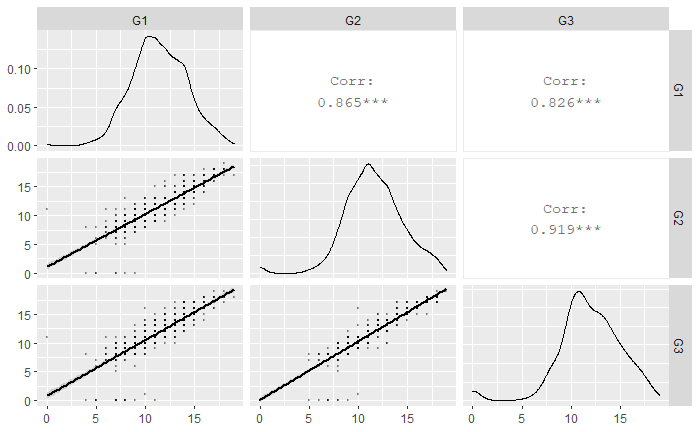

```r
student %>% ggpairs(columns = c("G1", "G2", "G3"),
                     lower = list(continuous = wrap("smooth", alpha = 0.3, size=0.1)))
```

The correlation is strong between the different grades and strongest between ‘G2’ and ‘G3’. They are also all positively related too each other. Finally they all seem to be normally distributed and left-skewed.

# Unsupervised machine learning

## PCA

Since the result of the PCA will be used to make a classification and the ‘G3’ variable is the response variable it is removed from the data set along with the numerical variations of it. The pass variable is a string and therefore has no effect on the PCA.

```r
student <- student %>%
  select(-grade, -G3, -grade_level)
```

First the PCA is created and plotted based on all the numerical values in the data set. According to the earlier findings in the EDA all values are scaled.

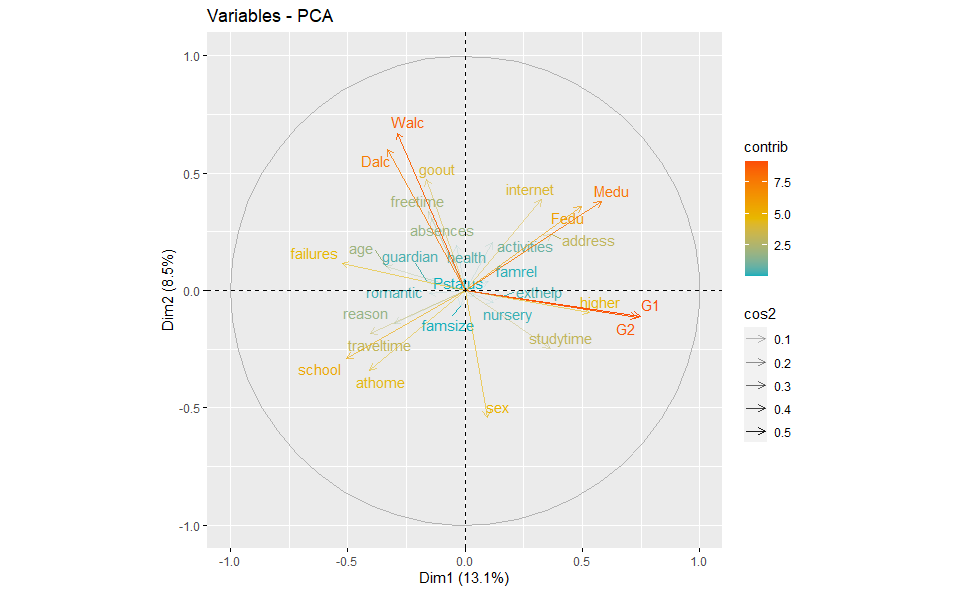

```r
res_pca <- student %>%
  select_if(is_numeric) %>%
  PCA(scale.unit = TRUE, graph = FALSE)

res_pca %>%
  fviz_pca_var(alpha.var = "cos2",
               col.var = "contrib",
               gradient.cols = c("#00AFBB", "#E7B800", "#FC4E07"),
               repel = TRUE,
               ggtheme = theme_gray())
```

In order to be able to select the optimal number of principal components a table of the eigenvalues, percentage of explained variance and the cumulative percentage of variance is created.

```r
res_pca$eig
```

```
        eigenvalue percentage of variance cumulative percentage of variance
comp 1   3.7878375             13.0615087                          13.06151
comp 2   2.4746619              8.5333169                          21.59483
comp 3   1.7143520              5.9115585                          27.50638
comp 4   1.4149280              4.8790621                          32.38545
comp 5   1.3900337              4.7932197                          37.17867
comp 6   1.2585320              4.3397654                          41.51843
comp 7   1.2260907              4.2278990                          45.74633
comp 8   1.1712609              4.0388307                          49.78516
comp 9   1.1051635              3.8109087                          53.59607
comp 10  1.0107744              3.4854290                          57.08150
comp 11  0.9960444              3.4346357                          60.51613
comp 12  0.9655472              3.3294731                          63.84561
comp 13  0.9242822              3.1871800                          67.03279
comp 14  0.9049700              3.1205861                          70.15337
comp 15  0.8573392              2.9563420                          73.10972
comp 16  0.7962835              2.7458053                          75.85552
comp 17  0.7951458              2.7418821                          78.59740
comp 18  0.7354566              2.5360573                          81.13346
comp 19  0.6862595              2.3664122                          83.49987
comp 20  0.6773921              2.3358348                          85.83571
comp 21  0.6483524              2.2356978                          88.07141
comp 22  0.6074169              2.0945411                          90.16595
comp 23  0.5870969              2.0244721                          92.19042
comp 24  0.5297791              1.8268246                          94.01724
comp 25  0.4963075              1.7114051                          95.72865
comp 26  0.4842057              1.6696747                          97.39832
comp 27  0.3411422              1.1763525                          98.57468
comp 28  0.2867272              0.9887146                          99.56339
comp 29  0.1266169              0.4366101                         100.00000
```

Lastly the a PCA with 10 principal components is created as a data frame so it can be used in k-means clustering and supervised machine learning.

```r
res_pca <- student %>%
  select_if(is_numeric) %>%
  PCA(scale.unit = TRUE, ncp= 10, graph = FALSE)

res_pca_df<- as.data.frame(res_pca$ind$coord[,])
```

## Clustering with k-means

The first step to doing a k-means clustering is to decide how many clusters to use. An elbow plot based on the total within sum of squares is useful for this task.

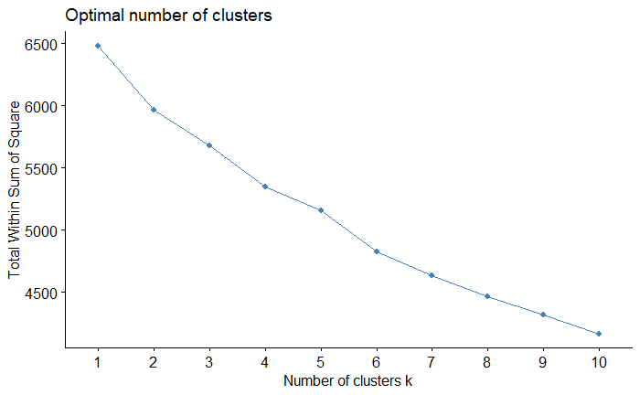

```r
res_pca_df %>%
  select_if(is.numeric) %>%
  scale() %>%
  fviz_nbclust(kmeans, method = "wss")
```

Though the elbow plot doesn’t show an obvious answer to the amount of clusters it can be argued that two clusters are the correct amount. This is based on the small kink in the curve at 2. Adding to this is the amount of binary variables that might play a role in cluster sorting.

The k-means clustering is then applied to the results of the previous PCA analysis. It has 2 clusters and runs 20 times.

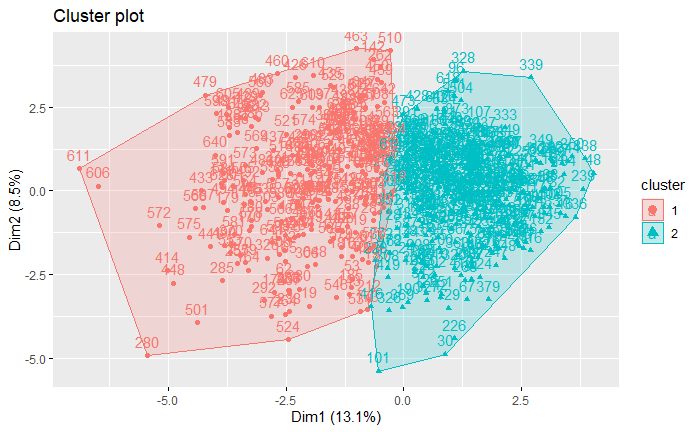

```r
res_pca_km <- kmeans(res_pca_df, centers=2, nstart=20)

res_pca_km %>%
  fviz_cluster(data = student %>% select_if(is_numeric),
               ggtheme = theme_gray())
```

The earlier PCA seems to be able to reduce the dimensionality in a way that makes it possible to create a somewhat clean division between the clusters.

Next task is to see which variables might explain how the individual observations are divided into clusters. This is done by adding the created cluster assignment to the data set.

```r
student <- student %>%
  bind_cols(cluster = res_pca_km$cluster)
```

Probability tables are used to investigate whether the variables have an effect on the division into clusters. The tables are presented first and used to create a plots of all the chosen variables. The interpretation will follow after the plots.

Since ‘G3’ is the variable of interest in this assignment one of the variations of it (in this case ‘pass’) is used to investigate whether the clustering is able to distinguish between the students that do well and the students who fail.

```r
table_pass<- table(student$cluster, student$pass)
table_pass_pct <- round(prop.table(table_pass,margin = 2), digits = 3) %>% print()
```

```
    FALSE  TRUE
  1 0.890 0.306
  2 0.110 0.694
```

```r
table_higher<- table(student$cluster, student$higher)
table_higher_pct <- round(prop.table(table_higher,margin = 2), digits = 3) %>% print()
```

```
        0     1
  1 0.971 0.328
  2 0.029 0.672
```

```r
table_fail<- table(student$cluster, student$failures)
table_fail_pct <- round(prop.table(table_fail,margin = 2), digits = 3) %>% print()
```

```
        0     1     2     3
  1 0.306 0.871 0.875 1.000
  2 0.694 0.129 0.125 0.000
```

```r
table_G2<- table(student$cluster, student$G2)
table_G2_pct <- round(prop.table(table_G2,margin = 2), digits = 3) %>% print()
```

```
        0     5     6     7     8     9    10    11    12    13    14    15    16    17    18    19
  1 1.000 1.000 1.000 0.938 0.900 0.750 0.675 0.476 0.116 0.162 0.056 0.053 0.000 0.100 0.000 0.000
  2 0.000 0.000 0.000 0.062 0.100 0.250 0.325 0.524 0.884 0.838 0.944 0.947 1.000 0.900 1.000 1.000
```

After creating the probability tables the results are used to create plots of the tables.

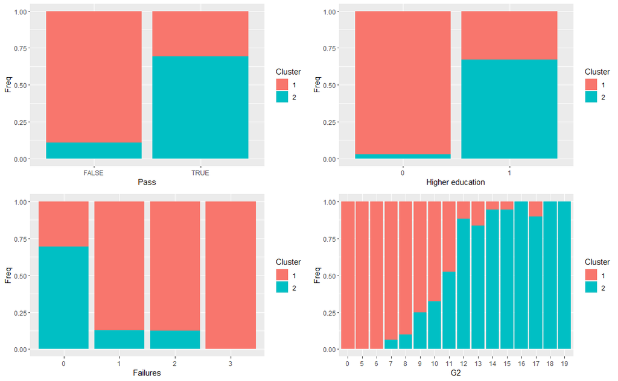

```r
gp <-  ggplot(data = as.data.frame(table_pass_pct),aes(x=Var2,y=Freq,fill=Var1)) +
    geom_col() + labs(x="Pass", fill = "Cluster")
gh <- ggplot(data = as.data.frame(table_higher_pct),aes(x=Var2,y=Freq,fill=Var1)) +
  geom_col() + labs(x="Higher education", fill = "Cluster")
gf <- ggplot(data = as.data.frame(table_fail_pct),aes(x=Var2,y=Freq,fill=Var1)) +
  geom_col() + labs(x="Failures", fill = "Cluster")
gg <- ggplot(data = as.data.frame(table_G2_pct),aes(x=Var2,y=Freq,fill=Var1)) +
  geom_col() + labs(x="G2", fill = "Cluster")

ggarrange(gp, gh, gf, gg)
```

There seems to be a common theme in the cluster assignment.

Cluster 1 generally contains people who do not do well in school:

- 89% of the students who do not obtain a passing grade is assigned to cluster 1
- 97% of the students who have no ambition of obtaining a higher education is assigned to cluster 1
- Only 31% of the students who have never failed a course is assigned to cluster 1
- The grade 10 is the highest grade in which students assigned to cluster 1 is the majority

Conversely cluster 2 generally contains people who do well in school.

# Supervised machine learning

The purpose of using supervised machine learning is to train and test models that can reliably predict the final grade (G3) of a student. Classification is used in this case since the level (low, medium or high) is more telling than a numerical value that needs further evaluation.

Since it is more manageable to perform classifications on fever outcomes the ‘grade_level’ variation of the ‘G3’ variable is chosen as the dependent variable. This means that the goal of the supervised machine learning is to predict whether any given student receives a low, medium or high final grade.

## Preprocessing

```r
res_pca_df$grade_level <- student_raw$grade_level
```

For simplicity and convinience the ‘grade_level’ variable is renamed ‘y’ and moved to the first column of the data set.

```r
student_class <- res_pca_df %>%
  rename(y = grade_level) %>%
  relocate(y)
```

The data set is split into two different parts. One part is used to train the machine learning models and the other is used to test it on how accurate it is. 75% of the data is used for training where as 25% is used for testing.

```r
student_split <- initial_split(student_class, prop = 0.75, strata = y)

student_train <- student_split  %>%  training()
student_test <- student_split %>% testing()
```

A general pipeline for data processing is created. This is to avoid doing this step for all the different models that are tested.

```r
student_recipe <- student_train %>%
  recipe(y ~.) %>%
  step_center(all_numeric(), -all_outcomes()) %>% # Centers all numeric variables to mean = 0
  step_scale(all_numeric(), -all_outcomes()) %>% # scales all numeric variables to sd = 1
  step_nzv(all_predictors())  %>% # Removed predictors with zero variance
  prep()
```

### Model creation

The first model type that is used is a decision tree. A decision tree aims to split the data set into homogeneous groups continuously until all decision nodes become terminal nodes.

```r
model_dt <- decision_tree(mode = 'classification',
                          cost_complexity = tune(),
                          tree_depth = tune(),
                          min_n = tune()
                          ) %>%
  set_engine('rpart')
```

The next model is a random forest. This model is simply a collection of decision trees where the outcome of the model is result produced by the majority of decision trees.

```r
model_rf <- rand_forest(mode = 'classification',
                        trees = 25, #number of trees choosen for the ensemble
                        mtry = tune(),
                        min_n = tune()
                        ) %>%
  set_engine('ranger', importance = 'impurity')
```

The last model is a XGboost tree. This model is a variation on the random forest where the focus is on training weak models to attain a strong one.

```r
model_xg <- boost_tree(mode = 'classification',
                       trees = 100, #number of trees choosen for the ensemble
                       mtry = tune(),
                       min_n = tune(),
                       tree_depth = tune(),
                       learn_rate = tune()
                       ) %>%
  set_engine("xgboost")
```

After defining the models the recipe from earlier is combined with the different models to create a workflow for each separate model.

```r
workflow_general <- workflow() %>% #Adding recipe to the general workflow
  add_recipe(student_recipe)

workflow_rf <- workflow_general %>% #Adding the models to the workflow
  add_model(model_rf)

workflow_dt <- workflow_general %>%
  add_model(model_dt)

workflow_xg <- workflow_general %>%
  add_model(model_xg)
```

The training data is then separated into k-folds (named v-fold) and training is repeated 3 times.

```r
student_resample <- student_train %>%
  vfold_cv(strata = y,
           v = 3, #three folds are chosen
           repeats = 3)
```

### Hyperparameter tuning

Since the models weren’t designed with specific parameter values, the parameters are tuned with the ‘tune_grid’ command.

```r
tune_dt <-
  tune_grid(
    workflow_dt,
    resamples = student_resample,
    grid = 10
  )
```

```r
tune_rf <-
  tune_grid(
    workflow_rf,
    resamples = student_resample,
    grid = 10
  )
```

```r
tune_xg <-
  tune_grid(
    workflow_xg,
    resamples = student_resample,
    grid = 10
  )
```

Since this is a classification problem the best model is chosen based on the ‘roc_auc’ metric for all the models.

```r
tune_dt %>% show_best(metric = 'roc_auc', n = 1)
```

| cost_complexity | tree_depth | min_n | .metric | .estimator | mean | n | std_err | .config |
| --- | --- | --- | --- | --- | --- | --- | --- | --- |
| 1.143274e-06 | 14 | 21 | roc_auc | hand_till | 0.8213013 | 9 | 0.01433323 | Model06 |

```r
best_param_dt <- tune_dt %>% select_best(metric = 'roc_auc')
```

The best decision tree model has a cost complexity of 1.14e-06, a tree depth of 14 and a minimum node size of 21. Since the cost complexity and minimum node size are low and the tree_depth is high it means that the tree doesn’t benefit from restraining its complexity.

```r
tune_rf %>% show_best(metric = 'roc_auc', n = 1)
```

| mtry | min_n | .metric | .estimator | mean | n | std_err | .config |
| --- | --- | --- | --- | --- | --- | --- | --- |
| 7 | 12 | roc_auc | hand_till | 0.8922108 | 9 | 0.006686863 | Model04 |

```r
best_param_rf <- tune_rf %>% select_best(metric = "roc_auc")
```

The best random forest selects 7 random variables at each split (mtry) and has a minimum node size of 12.

```r
tune_xg %>% show_best(metric = 'roc_auc', n = 1)
```

| mtry | min_n | tree_depth | learn_rate | .metric | .estimator | mean | n | std_err | .config |
| --- | --- | --- | --- | --- | --- | --- | --- | --- | --- |
| 4 | 14 | 14 | 0.05583568 | roc_auc | hand_till | 0.8704461 | 9 | 0.007087984 | Model01 |

```r
best_param_xg <- tune_xg %>% select_best(metric = 'roc_auc')
```

## Choosing the best model

After tuning the hyperparameters, the final workflow can be created.

```r
workflow_final_rf <- workflow_rf %>%
  finalize_workflow(parameters = best_param_rf) #adding the tuning to the existing workflow

workflow_final_dt <- workflow_dt %>%
  finalize_workflow(parameters = best_param_dt)

workflow_final_xg <- workflow_xg %>%
  finalize_workflow(parameters = best_param_xg)
```

The final models are fitted to the training data.

```r
fit_rf <- workflow_final_rf %>%
  fit(student_train)

fit_dt <- workflow_final_dt %>%
  fit(student_train)

fit_xg <- workflow_final_xg %>%
  fit(student_train)
```

### Comparing the models

A table is created by comparing the predicted values to the true values to evaluate the models performance.

```r
pred_collected <- tibble(
  truth = student_train %>% pull(y) %>% as.factor(), #Takes the true values from the training data
  rf = fit_rf %>% predict(new_data = student_train) %>% pull(.pred_class), #predicting y based on the training data and showing the predicted value
  dt = fit_dt %>% predict(new_data = student_train) %>% pull(.pred_class),
  xg = fit_xg %>% predict(new_data = student_train) %>% pull(.pred_class),
  ) %>%
  pivot_longer(cols = -truth,
               names_to = 'model',
               values_to = '.pred')

pred_collected %>% head()
```

| truth | model | .pred |
| --- | --- | --- |
| Medium | rf | Medium |
| Medium | dt | Low |
| Medium | xg | Medium |
| Medium | rf | Medium |
| Medium | dt | Medium |
| Medium | xg | Medium |

Based on the head of the prediction some models seems to predict correctly where as others get the prediction wrong.

To get a more thorough look at the models ability to accurately predict the outcomes the accuracy of the models are calculated.

```r
pred_collected %>%
  group_by(model) %>%
  accuracy(truth = truth, estimate = .pred) %>%
  select(model, .estimate) %>%
  arrange(desc(.estimate))
```

| model | .estimate |
| --- | --- |
| rf | 0.9713115 |
| xg | 0.8934426 |
| dt | 0.8504098 |

Based on the accuracy it seems that the random forest model is the best model for predicting the data.

## Fitting the last model

Since the random forest has been shown to be the most accurate that is the one chosen as the final model. This model then gets fitted to the ‘student_split’ and an importance plot is created to see which variables are most important in determining the outcome.

```r
fit_last_rf <- workflow_final_rf %>% last_fit(split = student_split)
```

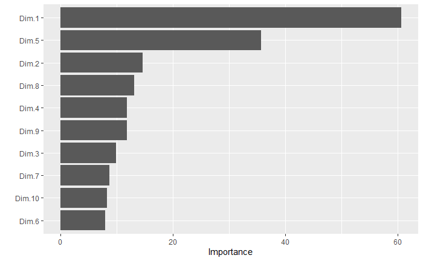

```r
fit_last_rf %>%
  pluck(".workflow", 1) %>%
  pull_workflow_fit() %>%
  vip::vip(num_features = 10)
```